# Parcial-2023

**Entrega:** 10 de octubre antes de las 16:00 horas, por correo electrónico con el título fundamentos-parcial, un solo documento (pdf/html) por equipo.

**Instrucciones:**

- Tus respuestas deben ser claras y debes explicar los resultados, incluye también tus procedimientos/código de manera ordenada, y el código comentado.
- Se evaluará la presentación de resultados (calidad de las gráficas, tablas, …), revisa la sección de visualización en las notas.
- Se puede realizar individual o en parejas.
- Si tienes preguntas puedes escribirlas en el anuncio de canvas del examen.

## Pruebas de hipótesis

Nos solicitan hacer un análisis con el objetivo de probar un material nuevo para suela de zapatos (el material B) y ver si es comparable con el material que se usa normalmente (el material A).

Nos dan el siguiente conjunto de datos:

```r
zapatos <- read_csv("datos/zapatos-1.csv")
zapatos
```

```
## # A tibble: 20 × 2
##    desgaste material
##       <dbl>    <dbl>
##  1     13.2        1
##  2     14          2
##  3      8.2        1
##  4      8.8        2
##  5     10.9        1
##  6     11.2        2
##  7     14.3        1
##  8     14.2        2
##  9     10.7        1
## 10     11.8        2
## 11      6.6        1
## 12      6.4        2
## 13      9.5        1
## 14      9.8        2
## 15     10.8        1
## 16     11.3        2
## 17      8.8        1
## 18      9.3        2
## 19     13.3        1
## 20     13.6        2
```

```r
# Convertimos material a factor
zapatos <- zapatos %>%
mutate(material = case_when(
    material == 1 ~ "A",
    material == 2 ~ "B",
    TRUE ~ as.character(material)  # Mantener otros valores como están
  ))
zapatos
```

```
## # A tibble: 20 × 2
##    desgaste material
##       <dbl> <chr>
##  1     13.2 A
##  2     14   B
##  3      8.2 A
##  4      8.8 B
##  5     10.9 A
##  6     11.2 B
##  7     14.3 A
##  8     14.2 B
##  9     10.7 A
## 10     11.8 B
## 11      6.6 A
## 12      6.4 B
## 13      9.5 A
## 14      9.8 B
## 15     10.8 A
## 16     11.3 B
## 17      8.8 A
## 18      9.3 B
## 19     13.3 A
## 20     13.6 B
```

1. Realiza una prueba de hipótesis visual y describe tus conclusiones (cuál es el nivel de significancia de la prueba?). `

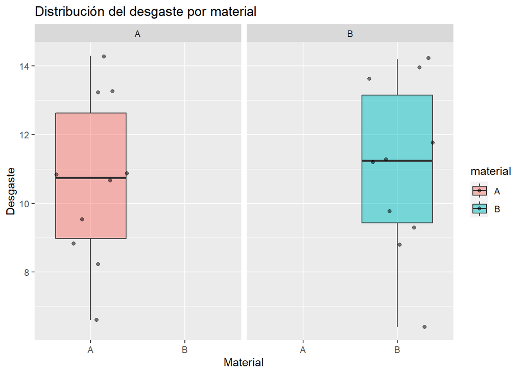

```r
# Graficamos la distribución de los desgastes por material
ggplot(zapatos, aes(x = material, y = desgaste)) +
  geom_boxplot(aes(fill = material), alpha = 0.5) +
  geom_jitter(aes(fill = material), alpha = 0.5) +
  labs(title = "Distribución del desgaste por material",
       x = "Material",
       y = "Desgaste") +
  facet_wrap(~ material)
```

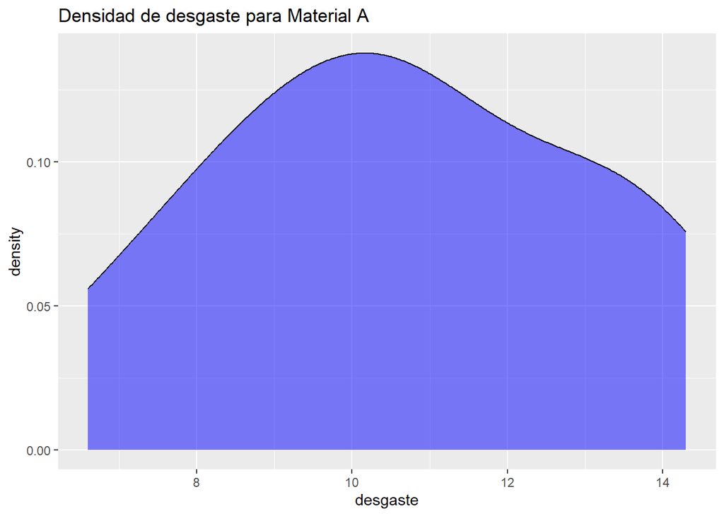

```r
library(ggplot2)

# Gráfico de densidad para Material A
ggplot(zapatos[zapatos$material == "A", ], aes(x = desgaste)) +
  geom_density(fill = "blue", alpha = 0.5) +
  labs(title = "Densidad de desgaste para Material A")
```

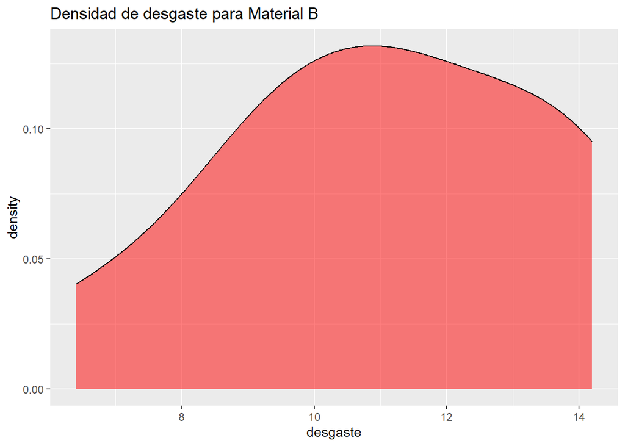

```r
# Gráfico de densidad para Material B
ggplot(zapatos[zapatos$material == "B", ], aes(x = desgaste)) +
  geom_density(fill = "red", alpha = 0.5) +
  labs(title = "Densidad de desgaste para Material B")
```

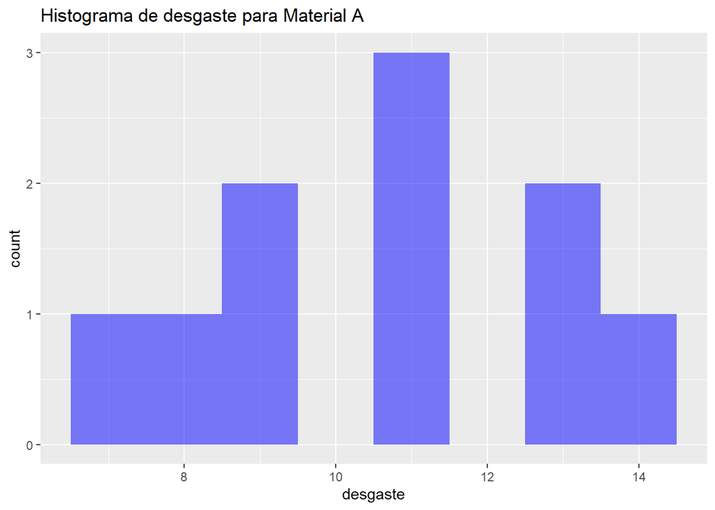

```r
# Histograma para Material A
ggplot(zapatos[zapatos$material == "A", ], aes(x = desgaste)) +
  geom_histogram(binwidth = 1, fill = "blue", alpha = 0.5) +
  labs(title = "Histograma de desgaste para Material A")
```

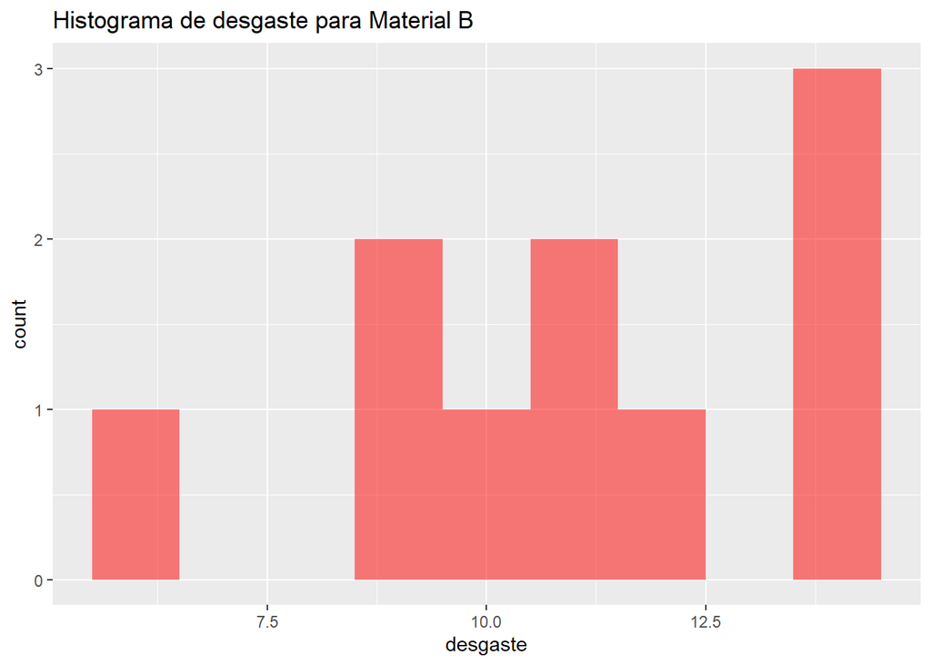

```r
# Histograma para Material B
ggplot(zapatos[zapatos$material == "B", ], aes(x = desgaste)) +
  geom_histogram(binwidth = 1, fill = "red", alpha = 0.5) +
  labs(title = "Histograma de desgaste para Material B")
```

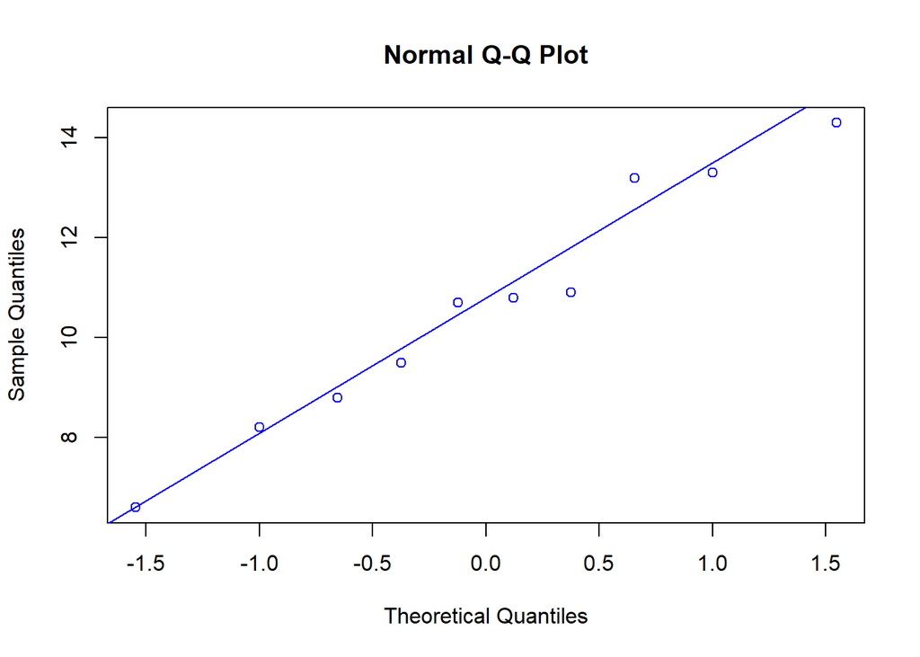

```r
# Gráfico Q-Q para Material A
qqnorm(zapatos$desgaste[zapatos$material == "A"], col = "blue")
qqline(zapatos$desgaste[zapatos$material == "A"], col = "blue")
```

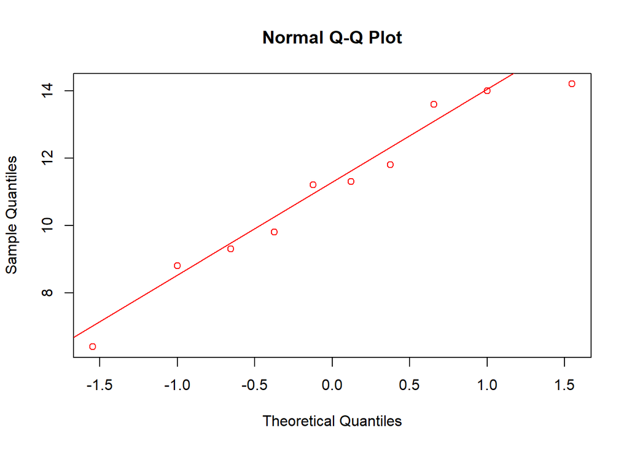

```r
# Gráfico Q-Q para Material B
qqnorm(zapatos$desgaste[zapatos$material == "B"], col = "red")
qqline(zapatos$desgaste[zapatos$material == "B"], col = "red")
```

```r
# Prueba de Shapiro-Wilk para material A
shapiro_test_A <- shapiro.test(zapatos$desgaste[zapatos$material == "A"])
shapiro_test_A
```

```
##
##  Shapiro-Wilk normality test
##
## data:  zapatos$desgaste[zapatos$material == "A"]
## W = 0.9624, p-value = 0.8129
```

```r
# Prueba de Shapiro-Wilk para material B
shapiro_test_B <- shapiro.test(zapatos$desgaste[zapatos$material == "B"])
shapiro_test_B
```

```
##
##  Shapiro-Wilk normality test
##
## data:  zapatos$desgaste[zapatos$material == "B"]
## W = 0.94815, p-value = 0.6467
```

Los valores de p (p-values) son altos (alpha generalmente = 0.05), lo que indica que no hay suficiente evidencia para rechazar la hipótesis nula (H0) de que los datos de desgaste para los materiales A y B siguen una distribución normal o no difieren significativamente de una distribución normal.

```r
# Prueba de igualdad de varianzas (Prueba de Levene)
library(car)  # Cargar la librería necesaria

levene_test_result <- leveneTest(desgaste ~ material, data = zapatos)
levene_test_result
```

```
## Levene's Test for Homogeneity of Variance (center = median)
##       Df F value Pr(>F)
## group  1  0.0113 0.9166
##       18
```

```r
# Prueba t de Student para comparar las medias
t_test_result <- t.test(desgaste ~ material, data = zapatos, var.equal = TRUE)
t_test_result
```

```
##
##  Two Sample t-test
##
## data:  desgaste by material
## t = -0.36891, df = 18, p-value = 0.7165
## alternative hypothesis: true difference in means between group A and group B is not equal to 0
## 95 percent confidence interval:
##  -2.744924  1.924924
## sample estimates:
## mean in group A mean in group B
##           10.63           11.04
```

Prueba de Igualdad de Varianzas (Prueba de Levene):

Estadístico de prueba F = 0.0113 Valor p = 0.9166 *Resultado*: No hay evidencia suficiente para rechazar la hipótesis nula de igualdad de varianzas entre los materiales A y B. Esto indica que se cumple el supuesto de igualdad de varianzas.

Prueba t de Student:

Estadístico t = -0.36891 Grados de libertad (df) = 18 Valor p = 0.7165

*Resultado:* No hay evidencia suficiente para rechazar la hipótesis nula de que las medias de desgaste son iguales entre los materiales A y B.No hay diferencias significativas en las medias de desgaste entre los materiales A y B.

Los datos de desgaste para los materiales A y B muestran igualdad de varianzas y no muestran diferencias significativas en las medias de desgaste. Por lo tanto, los dos materiales parecen comportarse de manera similar en términos de desgaste.

2. Realiza una prueba de permutaciones para la diferencia de las medias, escribe la hipótesis nula, la hipótesis alterna y tus conclusiones.

```r
# Cargamos las bibliotecas necesarias
library(readr)
library(dplyr)
library(ggplot2)


# Calculamos la diferencia observada entre los materiales A y B
diferencia_obs <- zapatos %>%
  group_by(material) %>%
  summarise(media_desgaste = mean(desgaste)) %>%
  arrange(material) %>%
  pull(media_desgaste) %>%
  diff()

# Creamos una función para realizar la prueba del lineup
lineup_test <- function(data, n_perm = 10000) {
  set.seed(123) # Establecemos una semilla para reproducibilidad
  obs_stat <- abs(diff(data))
  perm_stats <- replicate(n_perm, {
    permuted_data <- sample(data) # Permutamos los datos
    perm_stat <- abs(diff(permuted_data))
    perm_stat
  })

  p_value <- mean(perm_stats >= obs_stat)
  return(p_value)
}

# Realizamos la prueba de hipótesis visual
n_permutations <- 10000
p_value <- lineup_test(zapatos$desgaste, n_permutations)

# Nivel de significancia de la prueba
alpha <- 0.05

# Evaluamos si rechazamos o no la hipótesis nula
if (p_value <= alpha) {
  conclusion <- "Rechazamos la hipótesis nula"
} else {
  conclusion <- "No tenemos suficiente evidencia para rechazar la hipótesis nula"
}

# Imprimimos los resultados
cat("Diferencia observada entre A y B:", diferencia_obs, "\n")
```

```
## Diferencia observada entre A y B: 0.41
```

```r
cat("Valor p (nivel de significancia):", p_value, "\n")
```

```
## Valor p (nivel de significancia): 0.6635263
```

```r
cat("Conclusión:", conclusion, "\n")
```

```
## Conclusión: No tenemos suficiente evidencia para rechazar la hipótesis nula
```

3. Después de discutir con los responsables del proyecto descubrimos que nos faltaba conocer detalles del proceso generador de datos: el experimento se realizó asignando al azar un material a uno de sus zapatos y el otro material al otro zapato de cada niño. ¿Cómo incorporas esta información en tu prueba de hipótesis del inciso 2? ¿Cambian tus conclusiones?

```r
zapatos2 <- read_csv("datos/zapatos-2.csv")
zapatos2
```

```
## # A tibble: 20 × 3
##    desgaste material  niño
##       <dbl>    <dbl> <dbl>
##  1     13.2        1     1
##  2     14          2     1
##  3      8.2        1     2
##  4      8.8        2     2
##  5     10.9        1     3
##  6     11.2        2     3
##  7     14.3        1     4
##  8     14.2        2     4
##  9     10.7        1     5
## 10     11.8        2     5
## 11      6.6        1     6
## 12      6.4        2     6
## 13      9.5        1     7
## 14      9.8        2     7
## 15     10.8        1     8
## 16     11.3        2     8
## 17      8.8        1     9
## 18      9.3        2     9
## 19     13.3        1    10
## 20     13.6        2    10
```

sí hay repercusiones en el diseño del estudio.

Hipótesis Nula H0: No hay diferencia en las diferencias de desgaste entre los materiales A y B cuando se comparan los dos zapatos de cada niño.

```r
# Calculamos la diferencia observada entre los materiales A y B
diferencia_obs <- zapatos2 %>%
  group_by(material) %>%
  summarise(media_desgaste = mean(desgaste)) %>%
  arrange(material) %>%
  pull(media_desgaste) %>%
  diff()

# Creamos una función para realizar la prueba de permutaciones para diferencias
lineup_test_diferencias <- function(data, n_perm = 10000) {
  set.seed(123) # Establecemos una semilla para reproducibilidad
  obs_stat <- abs(diff(data))
  perm_stats <- replicate(n_perm, {
    permuted_data <- sample(data) # Permutamos las diferencias
    perm_stat <- abs(diff(permuted_data))
    perm_stat
  })

  p_value <- mean(perm_stats >= obs_stat)
  return(p_value)
}

# Realizamos la prueba de hipótesis visual para diferencias
n_permutations <- 10000
p_value <- lineup_test_diferencias(zapatos$desgaste, n_permutations)

# Nivel de significancia de la prueba
alpha <- 0.05

# Evaluamos si rechazamos o no la hipótesis nula
if (p_value <= alpha) {
  conclusion <- "Rechazamos la hipótesis nula"
} else {
  conclusion <- "No tenemos suficiente evidencia para rechazar la hipótesis nula"
}

# Imprimimos los resultados
cat("Diferencia observada entre A y B:", diferencia_obs, "\n")
```

```
## Diferencia observada entre A y B: 0.41
```

```r
cat("Valor p (nivel de significancia):", p_value, "\n")
```

```
## Valor p (nivel de significancia): 0.6635263
```

```r
cat("Conclusión:", conclusion, "\n")
```

```
## Conclusión: No tenemos suficiente evidencia para rechazar la hipótesis nula
```

## Bootstrap

#### Antecedentes

En México, las elecciones tienen lugar un domingo, los resultados oficiales del proceso se presentan a la población una semana después. A fin de evitar proclamaciones de victoria injustificadas durante ese periodo el INE organiza un conteo rápido. Un conteo rápido es un procedimiento para estimar, a partir de una muestra aleatoria de casillas, el porcentaje de votos a favor de cada opción en la boleta.

##### Diseño de la muestra

El diseño utilizado en los conteos rápidos es *muestreo estratificado simple*, es decir:

1. se particionan las casillas de la pablación en estratos (cada casilla pertenece a exactamente un estrato), y
2. dentro de cada estrato se usa *muestreo aleatorio* para seleccionar las casillas que estarán en la muestra.

##### Estimación

Una de las metodolgías de estimación, que se usa en el conteo rápido (tanto de elecciones como en consultas) es *estimador de razón combinado*, con intervalos de 95% de confianza construidos con el método normal y error estándar bootstrap. En este ejercicio debes construir intervalos usando este procedimiento.

Para cada opción en la consulta (sí/no/nulos) usarás la muestra del conteo rápido para estimar los resultados de la consulta.

1. Calcula el estimador de razón combinado, para muestreo estratificado la fórmula es:

$$\hat{p}=\frac{\sum_h \frac{N_h}{n_h}
\sum_i Y_{hi}}{\sum_h \frac{N_h}{n_h} \sum_i X_{hi}}$$
donde:

- $\hat{p}$ es la estimación de la proporción de votos que recibió la opción (ej: *sí*).
- $Y_{hi}$ es el número total de votos que recibió *la opción* (ej: *sí*) en la $i$-ésima casillas, que pertence al $h$-ésimo estrato.
- $X_{hi}$ es el número total de votos en la $i$-ésima casilla, que pertence al $h$-ésimo estrato.
- $N_h$ es el número total de casillas en el $h$-ésimo estrato.
- $n_h$ es el número de casillas del $h$-ésimo estrato que se seleccionaron en la muestra.